# FlipTheFleet Test Black Box Data: Codebook

EVBlackBox export 2018-06-10-233146.csv.gz

Ben Anderson (b.anderson@soton.ac.uk, `@dataknut`)

Last run at: 2018-11-12 12:58:06

# 1 About

## 1.1 License

This work is (c) the author(s).

This work is licensed under a [Creative Commons Attribution 4.0 International License](http://creativecommons.org/licenses/by/4.0/) unless otherwise marked.

For the avoidance of doubt and explanation of terms please refer to the full [license notice](https://creativecommons.org/licenses/by/4.0/) and [legal code](https://creativecommons.org/licenses/by/4.0/legalcode).

## 1.2 Citation

If you wish to use any of the material from this report please cite as:

- Anderson, B. (2018) FlipTheFleet Test Black Box Data: Codebook: (File: EVBlackBox export 2018-06-10-233146.csv.gz), [Centre for Sustainability](http://www.otago.ac.nz/centre-sustainability/), University of Otago: Dunedin, New Zealand.

This work is (c) 2018 the University of Southampton.

## 1.3 Purpose

This report is intended to:

- load and test preliminary ‘black box’ EV monitoring data provided for assessment purposes by [FlipTheFleet](http://flipthefleet.org/).

## 1.4 Requirements

- test dataset: EVBlackBox export 2018-06-10-233146.csv.gz

## 1.5 History

Specific history of this report:

- https://github.com/CfSOtago/evAnalysis/commits/master/ftf/dataProcessing/ftFBlackBoxTestDataCodebook.Rmd

## 1.6 Acknowledgements

Data provided by [FlipTheFleet](https://flipthefleet.org/ev-black-box/).

This work was supported by:

- The New Zealand [Ministry of Business, Innovation and Employment (MBIE)](http://www.mbie.govt.nz/) through the [Renewable Energy and the Smart Grid (GREEN Grid)](https://www.otago.ac.nz/centre-sustainability/research/energy/otago050285.html) project;
- [SPATIALEC](http://www.energy.soton.ac.uk/tag/spatialec/) - a [Marie Skłodowska-Curie Global Fellowship](http://ec.europa.eu/research/mariecurieactions/about-msca/actions/if/index_en.htm) based at the University of Otago’s [Centre for Sustainability](http://www.otago.ac.nz/centre-sustainability/staff/otago673896.html) (2017-2019) & the University of Southampton’s Sustainable Energy Research Group (2019-2020).

# 2 Load data files

In this section we load, merge and describe /Volumes/hum-csafe/Research Projects/GREEN Grid/externalData/flipTheFleet/raw/testData/EVBlackBox export 2018-06-10-233146.csv.gz.

Original data:

```
## Skim summary statistics
##  n obs: 12487
##  n variables: 144
##
## ── Variable type:character ───────────────────────────────────────────────────────────────────────────────────────────────────────
##    variable missing complete     n min max empty n_unique
##  Date (GPS)    1160    11327 12487  10  10     0       39
##      Reg No       0    12487 12487   6   6     0        1
##         VIN     163    12324 12487  10  16     0        2
##
## ── Variable type:difftime ────────────────────────────────────────────────────────────────────────────────────────────────────────
##    variable missing complete     n     min        max   median n_unique
##  Time (GPS)    1160    11327 12487 36 secs 86391 secs 03:46:32     8903
##
## ── Variable type:integer ─────────────────────────────────────────────────────────────────────────────────────────────────────────
##                 variable missing complete     n     mean       sd     p0
##              avg_cp (mV)     138    12349 12487  4441.28  4078.58   2811
##                     cp_1     138    12349 12487  3174.82  2372.61  -4110
##                    cp_10     138    12349 12487  3980.26  3862.48 -64784
##                    cp_11     138    12349 12487  3658.69  4343.36 -64014
##                    cp_12     138    12349 12487  4026.2   4036.14 -65039
##                    cp_13     139    12348 12487  3632.37  4378.55 -63503
##                    cp_14     139    12348 12487  3618.7   4323.64 -64783
##                    cp_15     139    12348 12487  3228.86  4615.84 -64527
##                    cp_16     139    12348 12487  3572.19  4383.25 -64782
##                    cp_17     139    12348 12487  3872.05  4087.45 -63246
##                    cp_18     139    12348 12487  3947.86  4035.15 -50703
##                    cp_19     139    12348 12487  3865.68  4100.5  -64526
##                     cp_2     138    12349 12487  3584.68  1702.91  -4112
##                    cp_20     139    12348 12487  3946.56  3997.24 -46095
##                    cp_21     139    12348 12487  4124.23  3864.29 -49423
##                    cp_22     139    12348 12487  4118.77  3898.07 -49423
##                    cp_23     139    12348 12487  4116.85  3925.22 -51471
##                    cp_24     139    12348 12487  4070.32  3975.32 -64527
##                    cp_25     139    12348 12487  4081.52  3934.05  -4108
##                    cp_26     139    12348 12487  4025.31  4006.23 -56591
##                    cp_27     139    12348 12487  4018.76  3940.31 -56591
##                    cp_28     139    12348 12487  4074.24  3940.73  -4103
##                    cp_29     139    12348 12487  3784.94  4249.21 -64526
##                     cp_3     138    12349 12487  3387.44  4785.94 -50785
```

[output cut: 197 more lines]

```
##    0      0      0    4095    ▇▁▁▁▁▁▁▁
##   17.6   20.2   21.8    28.4  ▁▁▂▅▇▆▃▁
##   16.8   19.4   21.1    27.7  ▁▂▂▅▇▆▃▁
##   16.4   19     20.7    26.2  ▁▁▂▅▆▇▃▁
##   15.5   18.2   20      25.1  ▁▂▂▆▇▇▅▁
##   -8.91  -8.15  -0.88   32.75 ▁▁▇▆▂▁▁▁
##  373.63 382.75 387.17 5783.52 ▇▁▁▁▁▁▁▁
##   42.41  60     74.56   95.53 ▁▂▃▆▆▇▇▃
##   72.22  72.31  72.38   72.86 ▁▁▁▁▁▁▁▇
##   72.22  72.31  72.38   72.86 ▁▁▁▁▁▁▁▇
##    0      0      0     103.71 ▇▁▁▁▁▁▁▁
##    0      0      0     102.08 ▇▁▁▁▁▁▁▁
##    0      0      0    1258    ▇▁▁▁▁▁▁▁
##    0      0      0    4092    ▇▁▁▁▁▁▁▁
##    0      0      0     199    ▇▁▁▁▁▁▁▁
```

# 3 Location inference

The raw data has latitude and longitude. This is very disclosive, although there are likely to be errors. For example 0 values in the table below (off the coast of West Africa) may indicate GPS signal issues.

Table 3.1: Summary of test geo data

|  | Longitude | Latitude | Altitude | ambient_temp_1 |
| --- | --- | --- | --- | --- |
|  | Min. : 0.0 | Min. :-36.87 | Min. :-293.50 | Min. : 0.00 |
|  | 1st Qu.:174.7 | 1st Qu.:-36.63 | 1st Qu.: 36.00 | 1st Qu.:11.00 |
|  | Median :174.7 | Median :-36.63 | Median : 39.80 | Median :14.00 |
|  | Mean :158.7 | Mean :-33.27 | Mean : 42.41 | Mean :13.03 |
|  | 3rd Qu.:174.7 | 3rd Qu.:-36.63 | 3rd Qu.: 44.20 | 3rd Qu.:16.00 |
|  | Max. :174.8 | Max. : 0.00 | Max. : 395.10 | Max. :22.00 |
|  | NA’s :12 | NA’s :12 | NA’s :12 | NA |

[interactive chart not shown]

Figure 3.1: Map of sample of observations

Figure 3.1 maps the location of a random sample of 50 of the observations in the dataset. If we selected just one vehicle and zoomed our map to the location at 01:00 - 04:00 when speed is 0 then we would probably determine their home. We could also determine other places visited at other times… This indicates how [disclosive GPS Lat/Long can be](http://toddwschneider.com/posts/analyzing-1-1-billion-nyc-taxi-and-uber-trips-with-a-vengeance/) even if address data is not provided.

# 4 Derived variables

Create some useful derived variables.

```r
# create derived
ftfDT <- evAnalysis::ftfCreateDerived(ftfDT)
```

If there is a ‘failed to parse’ message it suggests some dates and times could not be correctly parsed by `evAnalysis::ftfCreateDerived()`. We can check this using by comparing the original and parsed variables:

```
## Date (GPS)
```

```
##    Length     Class      Mode
##     12487 character character
```

```
## Time (GPS)
```

```
##   Length   Class1   Class2     Mode
##    12487      hms difftime  numeric
```

```
## rDateTime
```

```
##                  Min.               1st Qu.                Median
## "2018-05-01 12:42:27" "2018-05-08 03:57:40" "2018-05-18 02:16:05"
##                  Mean               3rd Qu.                  Max.
## "2018-05-20 04:32:05" "2018-06-02 03:58:09" "2018-06-11 09:40:28"
##                  NA's
##                "1160"
```

It looks like the dates don’t always parse. Check a few…

Table 4.1: Example rows where date failed to parse

| Date (GPS) | rDateTime | Time (GPS) |
| --- | --- | --- |
| NA | NA | NA |
| NA | NA | NA |
| NA | NA | NA |
| NA | NA | NA |
| NA | NA | NA |
| NA | NA | NA |

Doesn’t look like we can do much about these…

# 5 Preventing geo-disclosure

To avoid any risk of location disclosure we next infer a very coarse geo-location at each time point so that we can remove the potentially disclosive GPS data before moving on to the analysis.

Note that this does not necessarily render this dataset *completely safe* ([anonymised](https://www.ukdataservice.ac.uk/manage-data/legal-ethical/anonymisation)) as there may well be other variables that provide sufficient information either on their own or together which would [enable identification](https://www.ukdataservice.ac.uk/manage-data/legal-ethical/anonymisation) of the car and it’s owner.

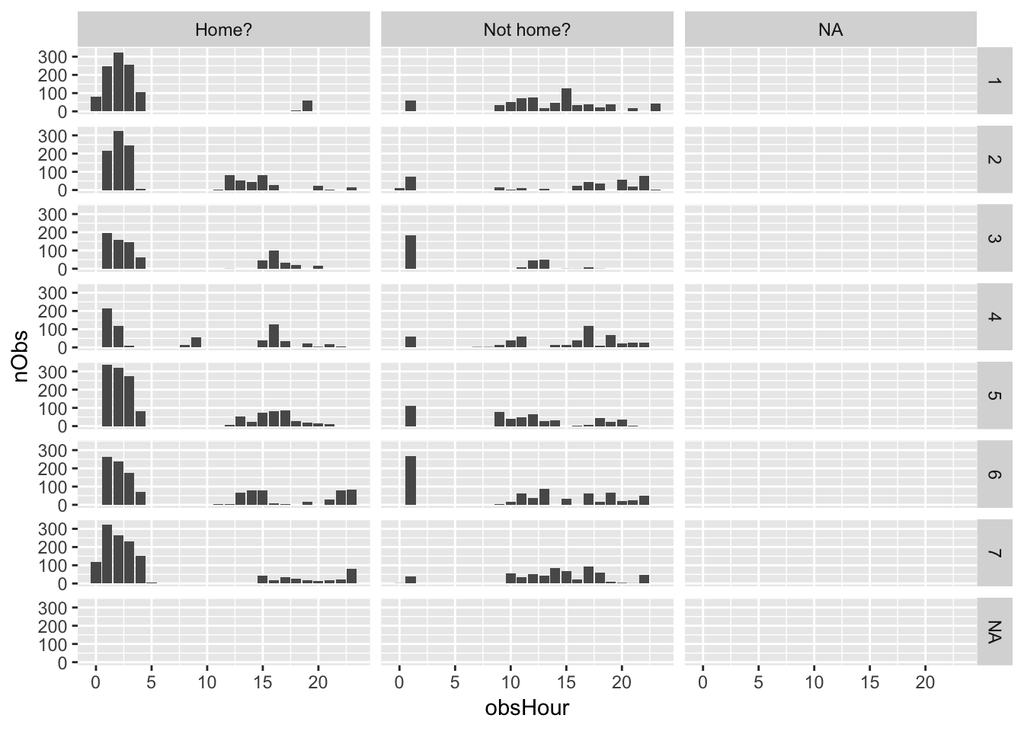

Figure 5.1: Check inferred location

```r
plotDT <- ftfDT[, .(nObs = .N),
                keyby = .(derivedLocation, obsHour = lubridate::hour(rDateTime), rDow = lubridate::wday(rDateTime))]

ggplot(plotDT, aes(x = obsHour, y = nObs)) +
  geom_col() +
  facet_grid(rDow ~ derivedLocation)
```

Figure 5.1 shows the results of this inference. Does it look like a reasonable guestimate of location?

# 6 Make safe version

We now create a unique EV ID by hashing the `Reg No` and then removing the following variables before we do anything else as they are potentially disclosive:

- `Reg No`
- `Latitude`
- `Longitude`
- `Course (deg)`

That gives us a data file with:

- 12,487 rows of data
- 147 columns (variables)
- 1 EVs

# 7 Codebook

Describe data to create codebook:

```
## ftfSafeDT
##
##  147  Variables      12487  Observations
## ---------------------------------------------------------------------------
## Time after power on (s)
##        n  missing distinct     Info     Mean      Gmd      .05      .10
##    12487        0     5845        1     3778     3908    145.0    292.6
##      .25      .50      .75      .90      .95
##    784.0   2486.0   6028.5   9269.8  11088.5
##
## lowest :    30    31    32    33    34, highest: 16530 16547 16575 16592 16636
## ---------------------------------------------------------------------------
## Date (GPS)
##        n  missing distinct
##    11327     1160       39
##
## lowest : 01-05-2018 01-06-2018 02-05-2018 02-06-2018 03-05-2018
## highest: 25-05-2018 28-05-2018 29-05-2018 30-05-2018 31-05-2018
## ---------------------------------------------------------------------------
## Time (GPS) [secs]
##        n  missing distinct
##    11327     1160     8903
##
## lowest : 00:00:36 00:00:37 00:00:38 00:01:04 00:01:16
## highest: 23:58:54 23:59:07 23:59:35 23:59:40 23:59:51
## ---------------------------------------------------------------------------
## Altitude
##        n  missing distinct     Info     Mean      Gmd      .05      .10
##    12475       12      988    0.999    42.41     22.6     0.00    24.50
##      .25      .50      .75      .90      .95
##    36.00    39.80    44.20    74.36    89.00
##
## lowest : -293.5   -4.3    0.0   10.7   10.8, highest:  161.9  163.8  169.6  361.6  395.1
## ---------------------------------------------------------------------------
## Speed (GPS)
##        n  missing distinct     Info     Mean      Gmd      .05      .10
##    12475       12       57    0.436    10.35    17.97     0.00     0.00
##      .25      .50      .75      .90      .95
##     0.00     0.00     0.00    53.71    79.64
##
```

[output cut: 1199 more lines]

```
##
## Value          Home? Not home?
## Frequency       7588      4887
## Proportion     0.608     0.392
## ---------------------------------------------------------------------------
## evID
##                                n                          missing
##                            12487                                0
##                         distinct                            value
##                                1 b4ed70fa9b8d2419411908df6d78ee2a
##
## Value      b4ed70fa9b8d2419411908df6d78ee2a
## Frequency                             12487
## Proportion                                1
## ---------------------------------------------------------------------------
```

# 8 Save safe data out

Save the safe data for future use and gzip it.

```
## Gziping /Volumes/hum-csafe/Research Projects/GREEN Grid/externalData/flipTheFleet/safe/EVBlackBox export 2018-06-10-233146.csv.gz_safe.csv
```

```
## Gzipped /Volumes/hum-csafe/Research Projects/GREEN Grid/externalData/flipTheFleet/safe/EVBlackBox export 2018-06-10-233146.csv.gz_safe.csv
```

Gzipped the file to reduce it from 10.53 MB to 1.55 MB.

# 9 Runtime

Analysis completed in 7.21 seconds ( 0.12 minutes) using knitr in [RStudio](http://www.rstudio.com) with R version 3.5.1 (2018-07-02) running on x86_64-apple-darwin15.6.0.

# 10 R environment

R packages used:

- base R - for the basics (R Core Team 2016)
- data.table - for fast (big) data handling (Dowle et al. 2015)
- lubridate - date manipulation (Grolemund and Wickham 2011)
- ggplot2 - for slick graphics (Wickham 2009)
- readr - for csv reading/writing (Wickham, Hester, and Francois 2016)
- Hmisc - for describe (Harrell Jr, Charles Dupont, and others. 2016)
- knitr - to create this document & neat tables (Xie 2016)
- evAnalysis - for local EV data utilities

# References

Dowle, M, A Srinivasan, T Short, S Lianoglou with contributions from R Saporta, and E Antonyan. 2015. *Data.table: Extension of Data.frame*. https://CRAN.R-project.org/package=data.table.

Grolemund, Garrett, and Hadley Wickham. 2011. “Dates and Times Made Easy with lubridate.” *Journal of Statistical Software* 40 (3): 1–25. http://www.jstatsoft.org/v40/i03/.

Harrell Jr, Frank E, with contributions from Charles Dupont, and many others. 2016. *Hmisc: Harrell Miscellaneous*. https://CRAN.R-project.org/package=Hmisc.

R Core Team. 2016. *R: A Language and Environment for Statistical Computing*. Vienna, Austria: R Foundation for Statistical Computing. https://www.R-project.org/.

Wickham, Hadley. 2009. *Ggplot2: Elegant Graphics for Data Analysis*. Springer-Verlag New York. http://ggplot2.org.

Wickham, Hadley, Jim Hester, and Romain Francois. 2016. *Readr: Read Tabular Data*. https://CRAN.R-project.org/package=readr.

Xie, Yihui. 2016. *Knitr: A General-Purpose Package for Dynamic Report Generation in R*. https://CRAN.R-project.org/package=knitr.